# PARCIAL # 1

CRISTIAN ALONSO CARDONA - KEVIN ANDRES MACIAS OCAMPO

24/3/2022

### 1.

La tabla mostrada contiene valores de población, en cientos de miles, de las diez ciudades más pobladas de cuatro países en el año 1967: Argentina EE. UU. Holanda Japón 29.66 77.81 8.68 110.21 7.61 35.50 7.31 32.14 6.35 24.79 6.02 18.88 4.10 20.02 2.64 16.38 3.80 16.70 1.75 13.37 2.75 9.39 1.72 11.92 2.70 9.38 1.51 10.71 2.69 8.76 1.42 7.80 2.51 7.63 1.31 7.70 2.4 4 7.50 1.29 7.00

### DATOS

```r
poblacion <- c(29.66, 7.61, 6.35, 4.10, 3.8, 2.75, 2.70, 2.69, 2.51, 2.44,
               77.81, 35.50, 24.79, 20.02, 16.70, 9.39, 9.38, 8.76, 7.63, 7.5,
               8.68, 7.31, 6.02, 2.64, 1.75, 1.72, 1.51, 1.42, 1.31, 1.29,
               110.21, 32.14, 18.88, 16.38, 13.37, 11.92, 10.71, 7.8, 7.7, 7);
paises <- c("argentina","argentina","argentina","argentina","argentina","argentina",
            "argentina","argentina","argentina","argentina","usa","usa","usa","usa","usa",
            "usa","usa","usa","usa","usa","holanda", "holanda", "holanda","holanda","holanda",
            "holanda","holanda","holanda","holanda","holanda","japon", "japon",
            "japon","japon","japon","japon","japon","japon","japon","japon");
paises <- factor(paises); paises
```

```
##  [1] argentina argentina argentina argentina argentina argentina argentina
##  [8] argentina argentina argentina usa       usa       usa       usa
## [15] usa       usa       usa       usa       usa       usa       holanda
## [22] holanda   holanda   holanda   holanda   holanda   holanda   holanda
## [29] holanda   holanda   japon     japon     japon     japon     japon
## [36] japon     japon     japon     japon     japon
## Levels: argentina holanda japon usa
```

### TAMAÑO

```r
length(poblacion);
```

```
## [1] 40
```

```r
length(paises);
```

```
## [1] 40
```

Punto A

Construya un box-plot e identifique los puntos extremos. ¿Cuáles son las características más sobresalientes? ¿Hay outliers?

Punto B

Compare los centros de cada población, sus dispersiones y su simetría. ¿Cuál es el país más homogéneamente habitado? ¿Cuáles son las características más sobresalientes? ¿Hay outliers?

### DESARROLLO

```r
mediageneral = tapply(poblacion, paises, mean); mediageneral
```

```
## argentina   holanda     japon       usa
##     6.461     3.365    23.611    21.748
```

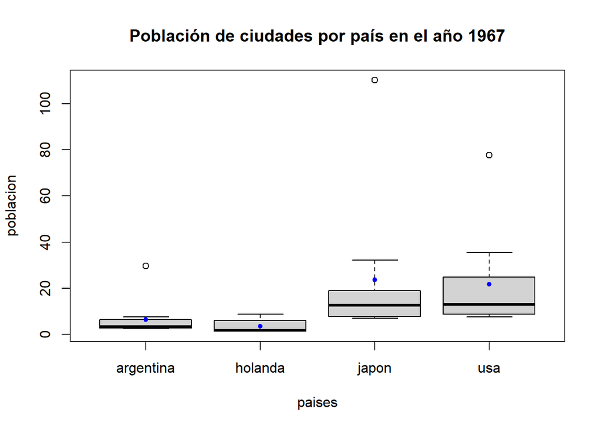

```r
bplot = boxplot(poblacion~paises, main='Población de ciudades por país en el año 1967');

xi <-  seq(bplot$n)
points(xi, mediageneral, col = 'blue', pch=20);
```

```r
desvest = tapply(poblacion, paises, sd); desvest
```

```
## argentina   holanda     japon       usa
##  8.340645  2.837328 31.329551 21.721691
```

### ANALISIS

PunTo B

Holanda es el pais con los datos más agrupados (menos dispersos). Japon es el pais con los datos más dispersos debe ser que en una cuidad tiene 110.21 de cientos de miles de habitantes, Holanda no tiene outliers.

## 2.

Avianca se encuentra estudiando la situación de venta de puesto en el vuelo Armenia – Bogotá puesto que ha identificado que el 2% de las personas que reservaron puesto, no se presentan a la hora del embarque. Teniendo en cuenta que el avión A320 utilizado en esta ruta tiene una capacidad para 180 pasajeros, la empresa decide vender 181 tiquetes. ¿Cuál es la probabilidad de que todas las personas que llegan a embarque puedan tener su silla asegurada y no se presenten quejas por “sobre-vender” sillas ante la aeronáutica civil? Asuma que las llegadas de los pasajeros siguen una distribución Poisson.

```r
probInasistenciaPasajeros <- 0.02
lambda <- round(180-(180*probInasistenciaPasajeros)); lambda
```

```
## [1] 176
```

```r
probMenor181Pasajeros <- ppois(181, lambda = lambda); probMenor181Pasajeros*100;
```

```
## [1] 66.45645
```

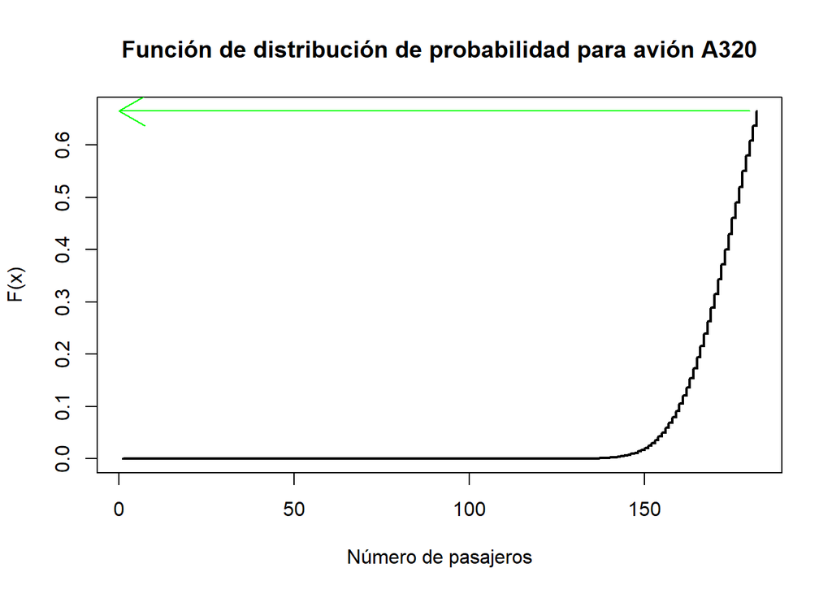

```r
plot = plot(ppois(0:181, 176), type = "s", lwd = 2,
     main = "Función de distribución de probabilidad para avión A320",
     xlab = "Número de pasajeros", ylab = "F(x)")+
arrows(180,probMenor181Pasajeros,0,probMenor181Pasajeros,col = 'green', pch=18);
```

### ANALISIS

Teniendo en cuenta los datos la probabilidad que todas las personas tengan una silla asugurada es de y no se presenten quejas por “sobre-vender” es de 66%

## 3.

En la planta envasadora de Coca-Cola FEMSA ubicada en Tocancipá se realiza el embotellado de la CocaCola presentación de 400 mL (en promedio), con una desviación estándar de 5 mL (mililitros). Si se sabe por experiencia que este proceso de embotellado sigue una distribución normal, y también se sabe que todo producto con más de 415 mL es declarado como NO CONFORME. Determine el porcentaje de las botellas de gaseosa que son declaradas producto NO CONFORME.

```r
media <- 400;
desvEstandar <- 5;
PNC <- 415;

probPNC <- pnorm(PNC, mean = media, sd = desvEstandar, lower.tail = FALSE);
porcentajePNC<-probPNC*100;
porcentajePNC;
```

```
## [1] 0.1349898
```

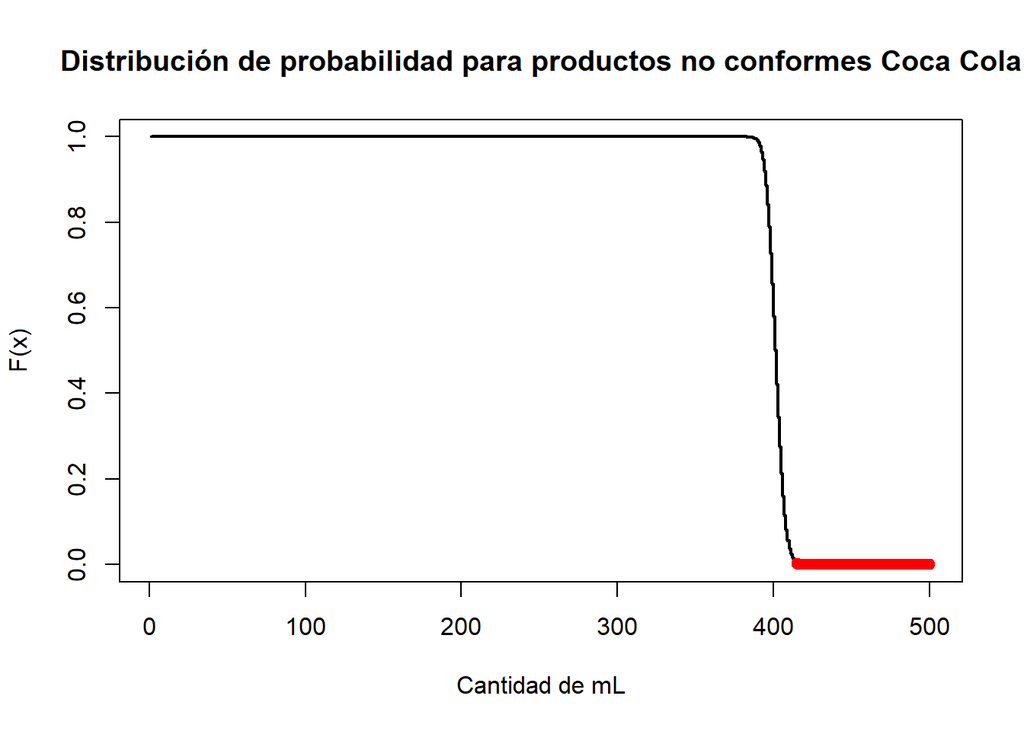

```r
plot = plot(pnorm(0:500, mean=media, sd = desvEstandar, lower.tail = FALSE), type = "s", lwd = 2,
     main = "Distribución de probabilidad para productos no conformes Coca Cola",
     xlab = "Cantidad de mL", ylab = "F(x)")+points(415:500,pnorm(415:500, mean=media, sd = desvEstandar, lower.tail = FALSE), col="red");
```

### ANALISIS

El porcentaje de las botellas de gaseosa que son declaradas producto NO CONFORME es de 0.1349898%.